# Data Wrangling with `dplyr`

Brian Fannin & Adam Rich

## Overview

Another element of `tidyverse` developed by Hadley Wickham and many others.

## Pipe review: `%>%`

The pipe is probably new to you. It takes a little getting used to. But once you get the hang of it, it is very intuitive.

- It takes whatever is to its **left** and
- inserts it as the first argument in the **function to its right**

Shortcut key is `CTRL-SHIFT-M`

## Pipe Example

Let’s get some data. It’s close to Halloween, so how about Bram Stoker’s *Dracula*?

```r
library(tidyverse)
dracula <- readr::read_file(
  'http://gutenberg.org/cache/epub/345/pg345.txt')
dracula_words <- strsplit(dracula, split = '\\s+')
```

## Chain of functions

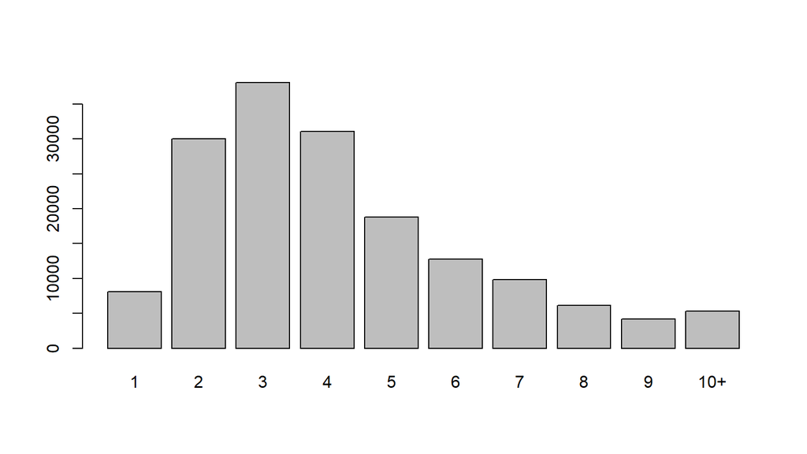

```r
words <- unlist(dracula_words)
words_lower <- tolower(words)
nchar_words <- nchar(words_lower)
nchar_words10 <- pmin(nchar_words, 10)
table_words10 <- table(nchar_words10)
barplot(table_words10, names.arg = c(1:9, '10+'))
```

That’s a lot of new variables.

## Combine as one

```r
unlist(dracula_words)
tolower(unlist(dracula_words))
nchar(tolower(unlist(dracula_words)))
pmin(nchar(tolower(unlist(dracula_words))), 10)
table(pmin(nchar(tolower(unlist(dracula_words))), 10))

# Fully nested!
barplot(table(pmin(nchar(tolower(unlist(dracula_words))), 10)), names.arg = c(1:9, '10+'))
```

That’s hard to read.

## Pipe it!

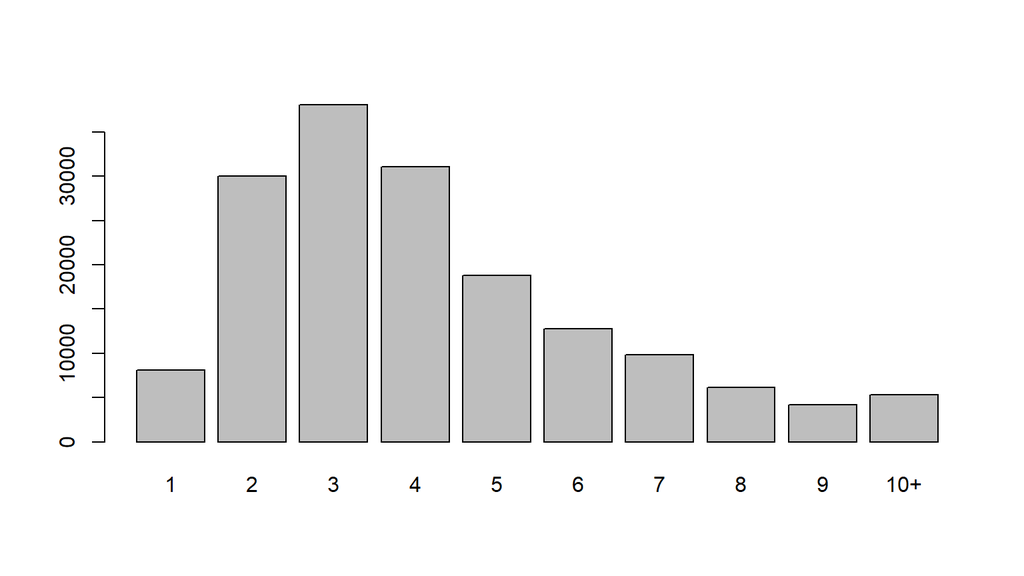

```r
dracula_words %>%
  unlist() %>%
  tolower() %>%
  nchar() %>%
  pmin(10) %>%
  table() %>%
  barplot(names.arg = c(1:9, '10+'))
```

## Back to `dplyr`

```r
library(raw)
data("MultiTri")
```

```r
str(MultiTri)
head(MultiTri)
```

## Real quick:

- What’s the average IBNR for lag 2 by accident year?

## dplyr to the rescue!

| Verbs |
| --- |
| select/rename |
| mutate |
| group |
| arrange |
| filter |
| summarize |

## `select` and `rename`

Comparable to the “select” verb in SQL. This will return only those columns you’ve requested. A “negative” column name will omit that column.

```r
financials <- MultiTri %>%
  dplyr::select(
    CumulativePaid, CumulativeIncurred, IBNR)

no_lag <- MultiTri %>%
  dplyr::select(-Lag)
```

## Identifying which columns to select

Loads of helper functions to find columns

| function |
| --- |
| `contains` |
| `starts_with` |
| `ends_with` |
| `matches` |
| `num_range` |

```r
years <- MultiTri %>%
  dplyr::select(contains("year"))
```

## `rename`

Closely related to `select`. New name on the left, old name on the right. (Think the way that variables are usually assigned.)

```r
new_tri <- MultiTri %>%
  rename(DevelopmentLag = Lag)
```

## `mutate`

Create a new column or alter an existing one.

```r
new_tri <- new_tri %>%
  mutate(
    PaidToIncurred = CumulativePaid / CumulativeIncurred,
    Upper = DevelopmentYear <= 1997)
```

## Aside: a note on assigment

**Re-using variable names invites problems**

The only time I think it is OK is when running the command more than once gives you the **exact same results**.

## Combining operations

```r
new_tri <- MultiTri %>%
  mutate(Upper = DevelopmentYear <= 1997) %>%
  dplyr::select(-DevelopmentYear)
```

## `arrange`

```r
MultiTri %>%
  arrange(AccidentYear)

MultiTri %>%
  arrange(desc(IBNR))
```

Use the `desc` function to arrange in descending order.

## `filter`

```r
upper_tri <- MultiTri %>%
  dplyr::filter(DevelopmentYear <= 1997)
```

Multiple conditions are OK

```r
upper_tri <- MultiTri %>%
  dplyr::filter(
    DevelopmentYear <= 1997,
    IBNR > 500)
```

## `slice`

Like `filter` but does numeric indexing to get specific rows of data.

```r
every_fifth <- MultiTri %>%
  slice(seq(from = 5, by = 5, to = nrow(MultiTri)))
```

## `group_by`

This will group the data. The effect isn’t material until another operation is applied.

```r
df_grouped <- MultiTri %>%
  group_by(Company, AccidentYear)
```

## `summarize`

```r
dfBigYear <- MultiTri %>%
  group_by(AccidentYear) %>%
  summarize(BiggestIBNR = max(IBNR))
```

## Answer a complex question quickly

For each company which has had paid to incurred ratio less than 40%, which accident year had the highest P2I?

```r
dfBigCase <- MultiTri %>%
  mutate(PaidToIncurred = CumulativePaid / CumulativeIncurred) %>%
  dplyr::filter(PaidToIncurred < 0.4) %>%
  group_by(Company) %>%
  arrange(desc(PaidToIncurred)) %>%
  slice(1) %>%
  dplyr::select(Company, AccidentYear)
```

## What about joining?

```r
dfCo <- data.frame(
  Company = unique(MultiTri$Company),
  stringsAsFactors = FALSE)

dfCo$PolicyHolderSurplus <- rnorm(
  nrow(dfCo), 1e8, 0.3 * 1e8)

print(dfCo)
```

```
##                             Company PolicyHolderSurplus
## 1             Farm Bureau Of MI Grp           105615338
## 2             West Bend Mut Ins Grp            74915051
## 3                Island Ins Cos Grp           137231492
## 4  Kentucky Farm Bureau Mut Ins Grp            92550745
## 5            Farmers Automobile Grp           115091193
## 6                State Farm Mut Grp            75922450
## 7            NC Farm Bureau Ins Grp           147611486
## 8                  Grinnell Mut Grp           130329815
## 9      New Jersey Manufacturers Grp           157312520
## 10                  Dorinco Rein Co           110155403
```

## Joining

```r
dfJoined <- dplyr::inner_join(MultiTri, dfCo)
dfJoined %>%
  dplyr::select(
    Company, PolicyHolderSurplus, DevelopmentYear) %>%
  head(3)
```

```
## # A tibble: 3 x 3
##   Company               PolicyHolderSurplus DevelopmentYear
##   <chr>                               <dbl>           <int>
## 1 Farm Bureau Of MI Grp          105615338.            1988
## 2 Farm Bureau Of MI Grp          105615338.            1989
## 3 Farm Bureau Of MI Grp          105615338.            1990
```

## What’s `tidyr`?

Does a number of things, but I’m only going to talk about 2: spreading and gathering

```r
library(tidyr)
one_co <- new_tri %>%
  dplyr::filter(
    Company == unique(MultiTri$Company)[1],
    Line == 'Workers Comp')
```

## `tidyr::spread`

```r
wide_tri <- one_co %>%
  dplyr::select(AccidentYear, Lag, NetEP, CumulativePaid) %>%
  tidyr::spread(Lag, CumulativePaid)

print(wide_tri)
```

```
## # A tibble: 10 x 12
##    AccidentYear NetEP   `1`   `2`   `3`   `4`   `5`   `6`   `7`   `8`   `9`
##           <int> <dbl> <dbl> <dbl> <dbl> <dbl> <dbl> <dbl> <dbl> <dbl> <dbl>
##  1         1988  7122  1346  3389  4666  5331  5719  6097  6126  6292  6368
##  2         1989  7588  1411  3641  4729  5352  5935  6032  6061  6222  6292
##  3         1990 10232  1424  4460  5791  6949  6966  7324  7596  7730  7827
##  4         1991 12731  2355  6208  8191  8368  8895  9162  9564  9654  9748
##  5         1992 16847  2544  7554  8008  9684 10637 10825 11131 11328 11406
##  6         1993 21327  3512  6745  9173 10286 10789 11233 11419 11558 11702
##  7         1994 21686  2708  7360 10084 11434 12277 12767 13076 13118 13749
##  8         1995 24955  2609  6240  8280  9507 10047 10393 10519 10653 10757
##  9         1996 22316  2652  5332  6822  7844  8179  8430  8706  9125  9095
## 10         1997 20975  2192  5320  7109  7779  8289  8550  8918  9027  9091
## # ... with 1 more variable: `10` <dbl>
```

## What about missing values?

```r
wide_tri <- one_co %>%
  dplyr::filter(Upper) %>%
  dplyr::select(AccidentYear, Lag, NetEP, CumulativePaid) %>%
  spread(Lag, CumulativePaid)
wide_tri
```

```
## # A tibble: 10 x 12
##    AccidentYear NetEP   `1`   `2`   `3`   `4`   `5`   `6`   `7`   `8`   `9`
##           <int> <dbl> <dbl> <dbl> <dbl> <dbl> <dbl> <dbl> <dbl> <dbl> <dbl>
##  1         1988  7122  1346  3389  4666  5331  5719  6097  6126  6292  6368
##  2         1989  7588  1411  3641  4729  5352  5935  6032  6061  6222  6292
##  3         1990 10232  1424  4460  5791  6949  6966  7324  7596  7730    NA
##  4         1991 12731  2355  6208  8191  8368  8895  9162  9564    NA    NA
##  5         1992 16847  2544  7554  8008  9684 10637 10825    NA    NA    NA
##  6         1993 21327  3512  6745  9173 10286 10789    NA    NA    NA    NA
##  7         1994 21686  2708  7360 10084 11434    NA    NA    NA    NA    NA
##  8         1995 24955  2609  6240  8280    NA    NA    NA    NA    NA    NA
##  9         1996 22316  2652  5332    NA    NA    NA    NA    NA    NA    NA
## 10         1997 20975  2192    NA    NA    NA    NA    NA    NA    NA    NA
## # ... with 1 more variable: `10` <dbl>
```

## `tidyr::gather`

Note that we’re *excluding* AccidentYear and Net EP from the gathering.

```r
long_tri <- wide_tri %>%
  tidyr::gather(Lag, CumulativePaid, -AccidentYear, -NetEP)
long_tri
```

```
## # A tibble: 100 x 4
##    AccidentYear NetEP Lag   CumulativePaid
##           <int> <dbl> <chr>          <dbl>
##  1         1988  7122 1               1346
##  2         1989  7588 1               1411
##  3         1990 10232 1               1424
##  4         1991 12731 1               2355
##  5         1992 16847 1               2544
##  6         1993 21327 1               3512
##  7         1994 21686 1               2708
##  8         1995 24955 1               2609
##  9         1996 22316 1               2652
## 10         1997 20975 1               2192
## # ... with 90 more rows
```

## What’s a tibble?

More or less a data frame.

- The print command won’t try to print every row in the tibble.
- They don’t automatically convert strings to factors
- add_row and add_column methods are kinda cool, especially add_row
- Some other stuff (no partial matching on column names)

## References

- http://www.tidyverse.org/
- http://dplyr.tidyverse.org/